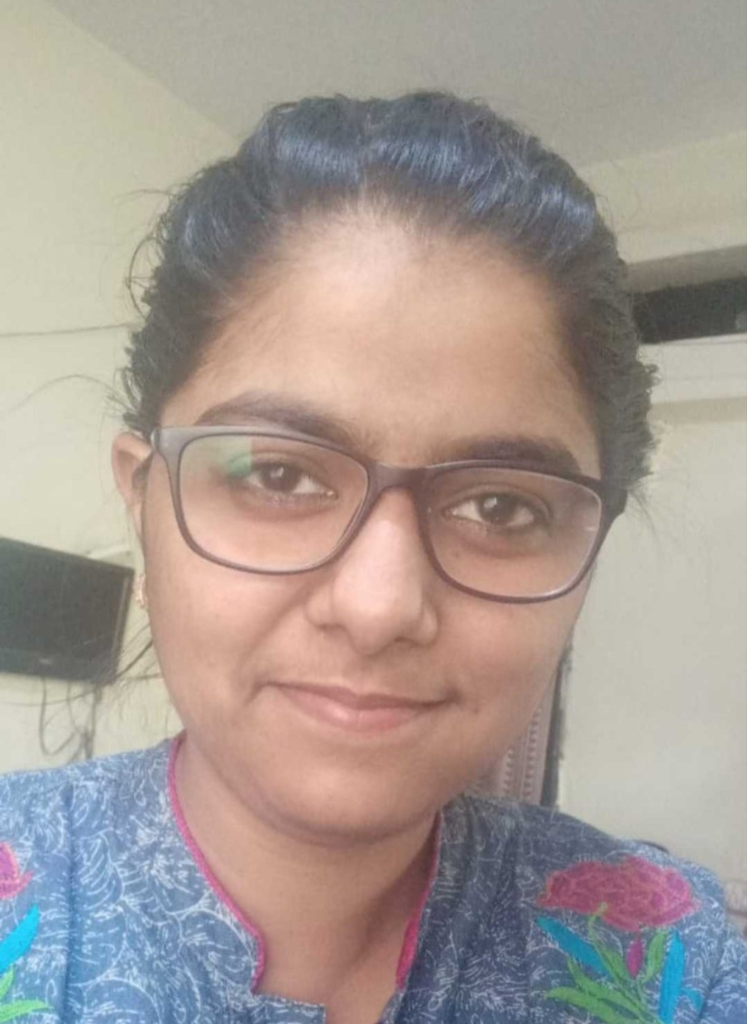

# Saranjeet Kaur Bhogal

I’m a Statistician by training, based in India (Asia). I’m interested in learning about open source and open science.

##### Open-source projects

[figure not shown]

Written the [R Development Guide](https://contributor.r-project.org/rdevguide/) in 2021 as a project funded by the [R Foundation](https://www.r-project.org/foundation/). Mentor: Heather Turner, Michael Lawrence.

[figure not shown]

Completed the [Google Summer of Code 2020](https://gist.github.com/SaranjeetKaur/37086fea06076bd3ec76d052cc166378) with the Turing team of the Julia language organisation. Mentor: Hong Ge, Cameron Pfiffer, Miles Lucas.

[figure not shown]

Created Zine for CarpenPi organization with a funding from the Data Science by Design (DSxD) initiative.

##### Upcoming Talks and Sessions

- [Collaboration Campfires: April 2022](https://contributor.r-project.org/events/collaboration-campfires)
- [Collaboration Campfires: May 2022](https://contributor.r-project.org/events/collaboration-campfires)

##### Previous Talks

[figure not shown]

[Lightning talk & Hack Day participation at CollabW22](https://github.com/SaranjeetKaur/RSEAsiaCW22): Presented a lightning talk on “RSE Asia Association: In making” at the Collaborations Workshop 2022 hosted by the Software Sustainability Institute. Also presented a pitch to build a `Carpentries-style Lesson on R's Bug Tracking Process` which secured the 3rd position on the Hack Day. As a part of this task we converted the materials from the Collaboration Campfires (on learning how to contribute to R) into a reusable lesson using The Carpentries Workbench template and the R package `sandpaper`. The lesson created is hosted on the [r-devel GitHub organization](https://github.com/r-devel/r-bug-tracking-lesson).

[figure not shown]

[Workshop talk at APAN53](https://github.com/SaranjeetKaur/APAN53_RSE_Asia): Presented a talk on “Research Software Engineering initiative in Asia region” at Asia Pacific Advanced Network (APAN53, Bangladesh). This talk was a part of the workshop on “Growing research software initiatives and communities in the Asia Pacific”.

[figure not shown]

[figure not shown]

[Lightning talk at PackagingCon 2021](https://youtu.be/BpRef4U-4sI?t=121): Presented a lightning talk on “Turing.jl: An Overview”. The talk was an overview of Turing.jl which is a Julia library focusing on Bayesian inference with probabilistic programming. This was the first edition of PackagingCon 2021, which is a conference held with the aim to bring various software eco-systems together.

[figure not shown]

[Invited talk at LatinR 2021](https://www.youtube.com/watch?v=VzPia_PAxvw): Presented a Invited talk on “R Development Guide: Motivation, First Draft, and the Way Forward”. This is a Latinamerican conference about the use of R in R&D.

[Virtual poster presentation at JuliaCon 2021](https://www.youtube.com/watch?v=Q7SYF3wbXwk): I presented a virtual poster of my work based on ‘Algorithmic Variants of Nested Sampling’. I developed these algorithms while working for the Google Summer of Code 2020 with the Turing team of the Julia Language organization. I also moderated the single track sessions of JuliaCon 2021.

[figure not shown]

[Regular talk at useR! 2021 - The R Conference](https://youtu.be/2B7H8WJOX40?t=2187https://youtu.be/2B7H8WJOX40?t=2187): In the ‘1A Community and Outreach 1’ session on the ‘R Developer’s Guide’ (now called as the ‘R Development Guide’). During the conference, I also attended the tutorials on ‘Contributing to R’ (conducted by Gabriel Becker and Martin Maechler) and ‘Translating R to Your Language’ (conducted by Michael Chirico and Michael Lawrence). I was also the Zoom Host for various tutorials and sessions of this international online conference.

##### Conference Moderator, Interviews, Podcast

- [The R Podcast](https://r-podcast.org/034-collaborative-campfires/)
- JuliaCon 2021 moderated sessions: [1](https://www.youtube.com/watch?v=IlFVwabDh6Q), [2](https://www.youtube.com/watch?v=LT4AP7CUMAw), [3](https://www.youtube.com/watch?v=sUyddZQaeyg), [4](https://www.youtube.com/watch?v=6V6jk_OdH-w)
- [Google Summer of Code AMA](https://www.youtube.com/watch?v=YPO9ew6EkkU)
- [Why R? World Interview](https://www.youtube.com/watch?v=0u-aJhXbLAM)

##### Community contributions

- Founding Committee Member, NumFOCUS Project Incubator, February 2022 – Present: The NumFOCUS Project Incubator would provide support for the growth of Open Source Scientific projects and communities. At the end of the incubation period, projects will have the required tools for becoming NumFOCUS Affiliated projects.
- Mentee, [Society of Research Software Engineering Pilot Mentorship Programme](https://society-rse.org/events/pilot-mentoring-programme/), November 2021 – Present: This is a 9-month non-technical mentoring program on topics such as personal development, communication, leadership, and career direction broadly in the field of Research Software Engineering. Working under the mentorship of Michelle Barker to further develop the community aspect of the RSE Asia Association of the RSE Asia Association.
- [Cohort participant, Digital Infrastructure Incubator](https://incubator.codeforscience.org/cohort), Code for Science & Society (CS&S). Mentor: Rayya El Zein.
- [Project Co-Lead, RSE Asia Association, Open Life Science Cohort-4](https://openlifesci.org/ols-4/projects-participants/). Mentor: Anne Fouilloux.
- Project Lead, R-Ladies Global, October 2020 – February 2022.
- Chapter Activity Tracking, R-Ladies Global, February 2020 – September 2020.
- Diversity Scholar, RStudio::Global 2021 conference.